# Digital media supporting literacy learning in children with communicative and cognitive disabilities

Lisa Palmqvist

1,2  
lisa.palmqvist@liu.se

Emil Holmer

1,2

More authors to be added

1, 2, 3,4

08 December, 2022

Abstract

# Introduction

## Hypotheses

1: Training phonic-based or comprehension-based reading strategies improves phonological awareness. 2: Training phonic-based or comprehension-based reading strategies improves reading ability. 3: The combined training is more effective than either intervention on its own.

The hypotheses will be tested on these outcome variables: phonological awareness (1, 3), word recognition (2, 3), and reading comprehension (2, 3).

# Methods

Data presented in this paper is collected in a larger project. Parts of the data has been used for this paper, for the purpose of this paper we have excluded for speech sound production which have been published in Samuelsson et al., (under revision). For a full description of collected data see (Palmqvist, Samuelsson, et al., 2020).

## Participants

Participants had to attend a Swedish special needs school, benefit from AAC, and be a beginning reader. To be enrolled in the Swedish special needs curriculum, the student needs an ID diagnosis according to the ICD-10. The diagnosis is based on a thorough medical, psychosocial, and psychological assessment. The teachers were instructed to identify students that would benefit from AAC and could not read more than approximately 20 words, which was the operationalization of being a beginning reader. No exclusion criteria were set for additional diagnoses, aetiology of the ID, or age. To reach the recruitment goal of at least 120 participants (see pre-registration, Palmqvist et al., 2020), recruitment included two waves, each consisting of two phases. In the first phase of each wave, teachers at special needs schools were contacted by email, asking whether they were interested in participating in the study. When giving a notification of interest, the teacher specified the number of students at their school that fulfilled the inclusion criteria. The teacher also provided information about the age and level of ID of those students, as well as estimated their adaptive and communication skill level. In the second phase of the recruitment process, teachers with an interest in participating in the study were asked to send information about the study to caregivers of potential participants, and for each student that were possible to include after caregivers had signed an informed consent, teachers provided an estimate of the number of words that the student could read. The information provided to the parents and students was written with easy-to-read language and supported with pictures. At the test session, the students preferred communication mode was used (i.e. if the students used AAC that AAC was used also in the test session). The testing was aborted at any sign of discomfort from the student. The study follows the Ethical principles for medical research involving human subjects from the WMA Declaration of Helsinki (World Medical Association, 2013), and approved by the Ethical Review Board, Sweden (2020-06215).  
In the first wave, 62 participants were recruited, and in the second wave, 75 additional participants, with a final sample of 137 participants ($n_{girls}$ = 58, $n_{boys}$ = 79). However, one participant was excluded due to testing not being followed as per protocol, and nine because their teacher-estimated level of word reading was higher than the cut-off applied (i.e., 20 words). Further, three participants dropped out of the study after the first testing session. The final sample thus included 124 participants ($n_{girls}$ = 54, $n_{boys}$ = 70), with a mean age of 13.7 (SD = 3.3 ) and mean IQ of 48 (SD = 13 ). Data on diagnoses were collected using parental surveys, see Table 1.

Table 1:

*Diagnoses in sample*

| Only ID | Autismspektrumtillstand | Downs syndrom | CP | ADHD/ADD | Other |
| --- | --- | --- | --- | --- | --- |
| 34 | 56 | 25 | 10 | 19 | 80 |

*Note.* Some participants can have more than one additional diagnosis

# Allocation of participants to reading instruction condition

One unsystematic (teaching-as-usual) and three different systematic approaches to reading instructions were applied in the present study: one applying a phonics-based reading strategy (using ALL), one applying a comprehension-based strategy (using Animega-is), and the third applying both strategies, referred to as the combination group (using ALL and Animega-is). The students that received teaching-as-usual comprised a comparison group. Allocation to the comparison group and the phonics-based reading strategy began after the first wave of recruitment, assigning 29 participations to the former, and 31 to the latter condition. An additional three participants from the second wave were allocated to the phonics-based reading strategy. Thirty-five of the remaining participants from the second wave were allocated to the comprehension-based reading instruction, and 31 to the combination group. For practical reasons, allocation was done on a school-basis, , i.e., all participants at one school were in the same group. To make sure that participants assigned to the different groups did not differ on relevant background variables, the information on adaptive and communicative skill, level of ID, and age, provided from the teachers when leaving their notification of interest, was used.

## Design

The study is a longitudinal between-group study, with four time points (before, during, after the intervention and a follow-up). Three intervention groups: one applying a phonic-based reading strategy (using ALL), one applying a comprehension-based strategy (using Animega-is), and the third applying both strategies (using ALL and Animega-is), and a comparison group who received regular teaching, not focusing one specific reading instruction strategy. Due to practical reasons, students were allocated to intervention groups on school-level, i.e., all participants at one school received the same intervention.

## Procedure

Testing took place in a silent environment at the participants’ school. The students were offered to have a teacher or an assistant present during the assessment. The students’ reading ability were assessed at four times, before (t1), during (t2; approx. at half-time), and after the intervention (t3) as well as at a 12-week follow-up (t4). For most of the test situations, t1 and t3 were administered by researchers, t2 and t4 were administered by a special need teacher or a school-based speech and language pathologist. Data was collected during the Covid19-pandemic, January 2020 to June 2021, thus, the test administrators were interchanged as schools introduced restrictions for visitors. Test administrators practiced the test procedure before data collection began. Test order was fixed over sessions and students. The test session lasted ~45-75 minutes, including short breaks. During breaks, students were offered a small snack, water, or to move around in the room for a few minutes.  
The literacy training took place in the participants’ school. The teachers were instructed to allow the students to train for 300 minutes (20 sessions for 15 min, five days a week for four weeks). The teachers were asked to not assist in solving the tasks for the children. The teacher was asked to administer the training as they saw fit for each student, meaning that they were able to split the training sessions into smaller sessions or train individually, or in group.

## Behavioral measures

The participants were assessed on non-verbal intelligence, phonological awareness, word recognition, and reading comprehension (in that order). All tests started with two practice items. All tests were adapted so that the student was able to give a non-verbal response option if preferred. All instructions were presented verbally in combination with complementary manual signs and pictures. A test was terminated if the student gave three consecutive incorrect responses, except for Raven’s where the test was terminated after six consecutive incorrect responses.

### Non-verbal intelligence

To estimate the participants’ IQ level, the Raven’s 2 Progressive Matrices Clinical Edition (Raven’s 2; Raven, Rust, Chan, & Zhou, 2018) was used. The three first modules (A, B, and C) were used, with a total of 36 items. IQ was calculated following the standardized procedure of the test and this was used as the dependent measure (with a minimum score of 40).

### Phonological awareness

To assess phonological awareness skills the subtests Phoneme synthesis, Phoneme identification, and Rhyme identification from MiniDUVAN (Wolff, 2013) were administered. Each subtest constituted of two practice items followed by nine test items. In the subtest Phoneme synthesis, the test leader pronounced a word segmented by three to five sounds. The participant was asked to identify the correct word by choosing between three pictures, one representing the correct word and two lures. For example, the test leader said “can you point at /s/ /u/ /n/”, with a break between each sound on approximately one second. In the subtest Phoneme identification, the participant was presented with a picture of the sun and asked to point to another picture with an object with the same initial phoneme in its name (e.g., “This is a sun. Sun starts with /s/. Point to the picture that start with the same sound /s/.”). The target phoneme was the same for all items. Three pictures were presented, one target and three lures. In the last subtest, Rhyme identification, the participant was asked to say whether two spoken words rhymed or not (e.g., “does hat – cat rhyme?”). The participant could choose to respond verbally, by pointing to pictures representing “yes” or “no”, or using a personal AAC mode. The dependent variable was total number of correct answers across all subtests (0-27).

### Word recognition

Two tests were used to assess word recognition skill; OS64 (Magnusson & Naucler, 2010) and OLAF (Magnusson & Naucler, 2010). In both tests, the student was asked to match a written word to a picture. Widget symbols were added to OS64 to enable non-verbal response. As the test had different number of maximum scores (OS64: 0-15, OLAF: 0-13), z-values were calculated based on the number of correct responses and a mean z-score was used as a dependent variable.

### Reading comprehension

In DLS Bas (Järpsten, 2004) the participant read short sentences and matched them to their corresponding picture. The degree of difficulty increased with each sentence, starting with a two-word sentence, and ending with a task consisting of two sentences with a total of 11 words. The dependent measure was total number of correct answers (max = 20).

## Materials: ALL and Animega-is

### A digital comprehension-based app: Animega-is

Animega-is has two different learning modes and both are adapted for use with AAC. In the create mode, the learner creates events with the help of text buttons, which are then followed by a animation corresponding to the event that was created. In the test mode, the learner can test his or her proficiency by first viewing the event, then choosing words and creating the sentence that best represents what he or she has just viewed. The app provides several levels of complexity as well as in-built comprehension tests. The app provides several levels of complexity as well as in-built comprehension tests. The language matter of the program is meant to be explored by the learner with help from -and in interaction with –a teacher. The language material and the appended animations not only offer motivational literacy training but also give room for conversations where the learner can express his or her imagination and thoughts. The goal is to achieve an errorless co-construction of meaning from text through multimedia and supportive interaction. There is also an editing possibility for the teacher to use. Here, the animations can be individualized by adding photos relevant to the child’s environment.

### A digital phonic-based app: Accessible Literacy Learning

The Accessible Literacy Learning (ALL) program is a program for literacy instruction for children with complex communication needs especially children with AAC (Light et al., 2008; Light & McNaughton, 2012, 2014). Only the modules using phonic training was used. The reading instruction includes: sound blending, phoneme segmentation, letter-sound correspondences, and phonological decoding. The exercises were accompanied by pictorial material/images to enable participation without speech.

## Statistical analysis

### Model building

# Results

Table 2:

*Descriptive statistics of included variables presented by group*

|  | $M_{control}$ | $SD_{control}$ | $(Range)_{control}$ | $M_{PB}$ | $SD_{PB}$ | $(Range)_{PB}$ | $M_{CB}$ | $SD_{CB}$ | $(Range)_{CB}$ | $M_{combi}$ | $SD_{combi}$ | $(Range)_{combi}$ | $p$ |
| --- | --- | --- | --- | --- | --- | --- | --- | --- | --- | --- | --- | --- | --- |
| Age | 13.7 | 3.24 | (9, 19) | 15.1 | 3.37 | (8, 22) | 12.3 | 3.56 | (7, 20) | 13.5 | 2.64 | (8, 18) | .069 |
| IQ | 43.2 | 5.3 | (40, 56) | 46.3 | 11.2 | (40, 91) | 52.3 | 14.8 | (40, 98) | 48.4 | 14.2 | (40, 98) | .189 |
| Instruction duration | 0 | 0 | (0, 0) | 414 | 225 | (83, 907) | 397 | 175 | (77, 760) | 362 | 182 | (85, 860) | .602 |
| Communication | 46.4 | 36.7 | (0, 99) | 64.7 | 35.5 | (0, 100) | 73.0 | 30.2 | (0, 100) | 72.5 | 28.8 | (0, 99) | .069 |

*Note.* Chronological age is presented in years.

Table 3:

*Descriptive statistics for the groups of predictor variables presented by time*

|  | $M_{T1}$ | $SD_{T1}$ | $(Range)_{T1}$ | $M_{T2}$ | $SD_{T2}$ | $(Range)_{T2}$ | $M_{T3}$ | $SD_{T3}$ | $(Range)_{T3}$ | $M_{T4}$ | $SD_{T4}$ | $(Range)_{T4}$ |
| --- | --- | --- | --- | --- | --- | --- | --- | --- | --- | --- | --- | --- |
| Comparison |  |  |  |  |  |  |  |  |  |  |  |  |
| PA | 10.3 | 8.39 | (0, 26) | 10.4 | 8.58 | (0, 25) | 10.1 | 9.55 | (0, 25) | 10.7 | 8.28 | (0, 27) |
| Word recognition | 0.34 | 0.42 | (0, 1) | 0.56 | 0.63 | (0, 2) | 0.45 | 0.51 | (0, 2) | 0.42 | 0.48 | (0, 1) |
| Reading comp | 0.16 | 0.47 | (0, 2) | 0.64 | 1.40 | (0, 4) | 0.27 | 0.80 | (0, 3) | 0.22 | 0.52 | (0, 2) |
| Phonic-based |  |  |  |  |  |  |  |  |  |  |  |  |
| PA | 12.8 | 8.06 | (0, 25) | 15.5 | 8.06 | (0, 26) | 14.7 | 8.43 | (0, 26) | 15.9 | 7.54 | (0, 27) |
| Word recognition | 0.52 | 0.48 | (0, 2) | 0.61 | 0.61 | (0, 2) | 0.68 | 0.53 | (0, 2) | 0.83 | 0.63 | (0, 2) |
| Reading comp | 0.34 | 1.29 | (0, 7) | 0.77 | 1.65 | (0, 7) | 0.97 | 2.82 | (0, 15) | 2.03 | 3.76 | (0, 16) |
| Comprehension-based |  |  |  |  |  |  |  |  |  |  |  |  |
| PA | 11.3 | 6.91 | (0, 25) | 12.2 | 7.82 | (0, 25) | 13.1 | 7.42 | (1, 27) | 13.9 | 8.06 | (0, 27) |
| Word recognition | 0.58 | 0.60 | (0, 2) | 0.67 | 0.69 | (0, 2) | 0.78 | 0.69 | (0, 2) | 0.95 | 0.67 | (0, 2) |
| Reading comp | 0.78 | 2.54 | (0, 13) | 1.43 | 3.35 | (0, 15) | 1.07 | 2.77 | (0, 14) | 2.82 | 5.06 | (0, 20) |
| Combination |  |  |  |  |  |  |  |  |  |  |  |  |
| PA | 12.8 | 7.92 | (0, 23) | 14.5 | 7.38 | (0, 25) | 16.1 | 6.87 | (0, 26) | 16.4 | 6.65 | (1, 26) |
| Word recognition | 0.62 | 0.46 | (0, 2) | 0.88 | 0.62 | (0, 2) | 0.77 | 0.58 | (0, 2) | 0.81 | 0.74 | (0, 3) |
| Reading comp | 0.27 | 0.91 | (0, 4) | 0.82 | 1.51 | (0, 7) | 0.56 | 1.87 | (0, 8) | 0.40 | 0.81 | (0, 3) |

## Intervention implementation

The instruction duration for each group can be seen in Figure 1).

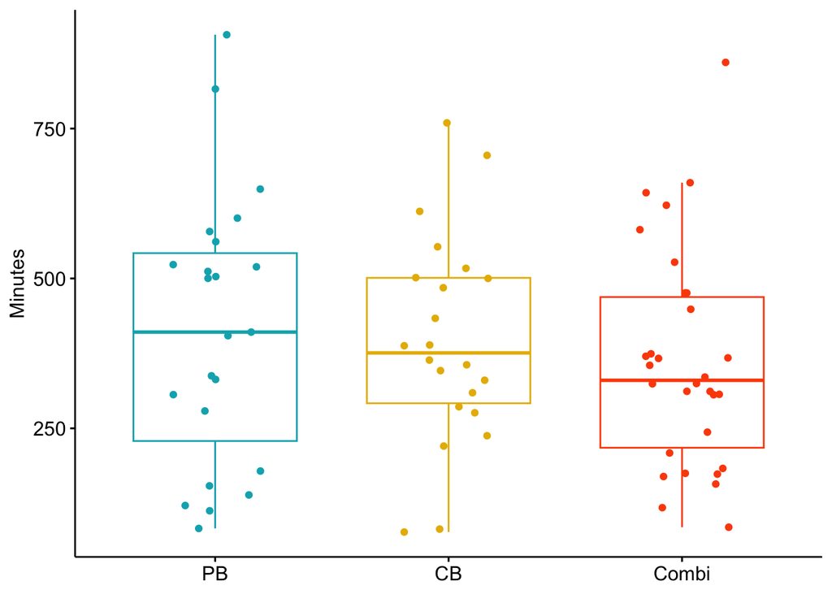

Figure 1: Duration of instruction in each group

## Phonological awareness

All groups improved in PA with time, $\hat{\beta} = 0.09$, 95% CI $[0.05, 0.13]$, $t(336.07) = 4.81$, $p < .001$, and the participants in the combination group improved more than the participants in the other groups, $\hat{\beta} = 0.09$, 95% CI $[0.03, 0.15]$, $t(333.59) = 2.78$, $p = .006$ . The effect of the phonics-based reading instruction, compared to the comparison group, approached statistical significance, $\hat{\beta} = 0.05$, 95% CI $[-0.01, 0.11]$, $t(335.92) = 1.66$, $p = .098$. However, the comprehension-based reading instruction did not lead to better development than the TAU approach in the comparison group, $\hat{\beta} = 0.04$, 95% CI $[-0.02, 0.10]$, $t(336.54) = 1.41$, $p = .159$. In sum, we found support for Hypothesis 3, but not for Hypotheses 1-2, see Table 4.

Table 4: Effects of Interventions on Phonological Awareness

|  | PA scale |  |  |
| --- | --- | --- | --- |
| Predictors | $\beta$ | CI | p |
| (Intercept) | 0.76 | 0.68 – 0.85 | **<0.001** |
| Days | 0.09 | 0.05 – 0.13 | **<0.001** |
| Control vs PB | 0.13 | -0.00 – 0.27 | 0.058 |
| Control vs CB | -0.03 | -0.17 – 0.12 | 0.723 |
| PB and CB vs Combi | 0.06 | -0.08 – 0.20 | 0.402 |
| Days*Control vs PB | 0.05 | -0.01 – 0.11 | 0.098 |
| Days*Control vs CB | 0.04 | -0.02 – 0.10 | 0.159 |
| Days*PB and CB vs Combi | 0.09 | 0.03 – 0.15 | **0.006** |
| Random Effects |  |  |  |
| σ<sup>2</sup> | 0.05 |  |  |
| τ<sub>00</sub> <sub>id</sub> | 0.19 |  |  |
| ICC | 0.78 |  |  |
| N <sub>id</sub> | 123 |  |  |
| Observations | 454 |  |  |
| Marginal R<sup>2</sup> / Conditional R<sup>2</sup> | 0.071 / 0.800 |  |  |

## Word recognition

For word recognition, participants improved with time, $\hat{\beta} = 0.14$, 95% CI $[0.09, 0.18]$, $t(137.71) = 5.53$, $p < .001$. This applied to all four groups, and neither PB ($\hat{\beta} = 0.04$, 95% CI $[-0.04, 0.11]$, $t(125.64) = 0.90$, $p = .372$), CB ($\hat{\beta} = 0.03$, 95% CI $[-0.05, 0.10]$, $t(114.03) = 0.70$, $p = .484$), nor the combination of the two instructions ($\hat{\beta} = -0.01$, 95% CI $[-0.09, 0.07]$, $t(154.22) = -0.18$, $p = .859$) led to a stronger development than what was observed in the comparison group. Thus, for word reading, we did not find support for Hypotheses 1-3, see Table 5.

Table 5: Effects of Interventions on Word Recognition

|  | word |  |  |
| --- | --- | --- | --- |
| Predictors | $\beta$ | CI | p |
| (Intercept) | 0.54 | 0.45 – 0.63 | **<0.001** |
| Days | 0.14 | 0.09 – 0.18 | **<0.001** |
| Control vs PB | 0.04 | -0.11 – 0.19 | 0.597 |
| Control vs CB | 0.09 | -0.06 – 0.25 | 0.230 |
| PB and CB vs Combi | 0.14 | -0.01 – 0.30 | 0.075 |
| Days*Control vs PB | 0.04 | -0.04 – 0.11 | 0.371 |
| Days*Control vs CB | 0.03 | -0.05 – 0.10 | 0.483 |
| Days*PB and CB vs Combi | -0.01 | -0.09 – 0.07 | 0.859 |
| Random Effects |  |  |  |
| σ<sup>2</sup> | 0.07 |  |  |
| τ<sub>00</sub> <sub>id</sub> | 0.22 |  |  |
| τ<sub>11</sub> <sub>id.days_scale</sub> | 0.01 |  |  |
| ρ<sub>01</sub> <sub>id</sub> | 0.49 |  |  |
| ICC | 0.80 |  |  |
| N <sub>id</sub> | 122 |  |  |
| Observations | 450 |  |  |
| Marginal R<sup>2</sup> / Conditional R<sup>2</sup> | 0.057 / 0.809 |  |  |

# Reading comprehension

There was a statistically significant effect of time, $\hat{\beta} = 0.59$, 95% CI $[0.35, 0.83]$, $z = 4.73$, $p < .001$, indicating that participants improved on reading comprehension, regardless of reading instruction condition. However, we did not see any effects of PB ($\hat{\beta} = 0.32$, 95% CI $[-0.03, 0.68]$, $z = 1.79$, $p = .073$), CB ($\hat{\beta} = -0.13$, 95% CI $[-0.47, 0.20]$, $z = -0.77$, $p = .440$), or the combination of the two instructions ($\hat{\beta} = -0.12$, 95% CI $[-0.55, 0.31]$, $z = -0.53$, $p = .598$). Thus, hypotheses 1-3 were not supported for reading comprehension, see Table 6.

Table 6: Effects of Interventions on Reading Comprehension

|  | DLS |  |  |
| --- | --- | --- | --- |
| Predictors | Incidence Rate Ratios | CI | p |
| (Intercept) | 0.06 | 0.03 – 0.12 | **<0.001** |
| Days | 1.80 | 1.41 – 2.30 | **<0.001** |
| Control vs PB | 1.07 | 0.43 – 2.66 | 0.883 |
| Control vs CB | 1.55 | 0.63 – 3.83 | 0.341 |
| PB and CB vs Combi | 0.98 | 0.38 – 2.53 | 0.964 |
| Days*Control vs PB | 1.38 | 0.97 – 1.97 | 0.073 |
| Days*Control vs CB | 0.88 | 0.62 – 1.23 | 0.440 |
| Days*PB and CB vs Combi | 0.89 | 0.58 – 1.37 | 0.598 |
| Random Effects |  |  |  |
| σ<sup>2</sup> | 2.41 |  |  |
| τ<sub>00</sub> <sub>id</sub> | 5.63 |  |  |
| ICC | 0.70 |  |  |
| N <sub>id</sub> | 122 |  |  |
| Observations | 449 |  |  |
| Marginal R<sup>2</sup> / Conditional R<sup>2</sup> | 0.041 / 0.712 |  |  |

# Results summary

# marginal and conditional R2

A marginal R2 close to zero tells us that the fixed effects aren’t explaining much variation, and a conditional R2 close to 1 tells us that most of that unexplained variation is between groups (people) rather than between observations within groups (people). So, for example, if the context was a longitudinal cohort study, we wouldn’t expect to improve our model much by collecting more data on characteristics/measures that mainly vary within people, but instead should find characteristics that mainly vary between people.

# Discussion

In line with earlier research, we found that reading can be taught to students with ID. Our research adds a large-scale study including students who also benefit from AAC, in practice children with lower cognitive level (i.e. IQ). Earlier literacy intervention studies for students with ID have mainly included children with mild ID, and the ones that have included moderate to severe have mostly been case studies. Our study conclude that even though IQ is important for the acquisition of reading, children with mild to moderate can also benefit from literacy instruction.

Reading builds on several simultaneous processes, and training programs on these instructional strategies inevitably overlap in the mechanisms that they activate. For example, a comprehension-based instructional strategy does not exclude the possibility to apply phonic-based principles as the meaning of words are sought and when working with a phonic-based approach, lexico-semantic processes (e.g., phonological structures in the lexicon, semantic associations) might influence training outcomes. Still, the emphasis is different across strategies, and it is reasonable to assume that they support development in different reading components.